## **Norwegian Spring Spawning Herring**

In this case study you learn to:

- run SAM for Norwegian Spring Spawning Herring.
- validate a SAM assessment.
- set TAC for herring.

In thic case study it is assumed that you have a good overview of how SAM works. If you want to learn more about the therory behind SAM and how it is implemented, see https://github.com/skaug/tmb-case-studies/tree/master/SAM for case studies which elaborate SAM.

To run a SAM model can be divided into five standard steps:

1. Read data
2. Set up SAM data
3. Set up configurations
4. Define parameters
5. Fit SAM

In this case study we illustrates how to modify these parts to use settings from XSAM. We start with fitting a standard SAM with the herring data, and then extend the model to include XSAM options currently used in the herring assessment.

### Standard SAM model

**Read data**

```r
  cn<-read.ices("data/Herring/cn.dat")
  cw<-read.ices("data/Herring/cw.dat")
  dw<-read.ices("data/Herring/dw.dat")
  lf<-read.ices("data/Herring/lf.dat")
  lw<-read.ices("data/Herring/lw.dat")
  mo<-read.ices("data/Herring/mo.dat")
  nm<-read.ices("data/Herring/nm.dat")
  pf<-read.ices("data/Herring/pf.dat")
  pm<-read.ices("data/Herring/pm.dat")
  sw<-read.ices("data/Herring/sw.dat")
  surveys<-read.ices("data/Herring/survey.dat")
```

**Setup SAM data**

```r
  dat<-setup.sam.data(surveys=surveys,
                      residual.fleet=cn,
                      prop.mature=mo,
                      stock.mean.weight=sw,
                      catch.mean.weight=cw,
                      dis.mean.weight=dw,
                      land.mean.weight=lw,
                      prop.f=pf,
                      prop.m=pm,
                      natural.mortality=nm,
                      land.frac=lf)
```

**Set configurations**

```r
  conf = loadConf(dat,"scripts/Herring/confStandard.cfg")
```

*Note: Use almost the default settings, we will later encounter some convergence issues if we use the default settings.*

**Define parameters**

```r
  par<-defpar(dat,conf)
```

**Fit SAM**

```r
  fitStandard<-sam.fit(dat,conf,par)
```

### SAM model with currently used XSAM options

**Read data**

```r
  cn<-read.ices("data/herring/cn.dat")
  cw<-read.ices("data/herring/cw.dat")
  dw<-read.ices("data/herring/dw.dat")
  lf<-read.ices("data/herring/lf.dat")
  lw<-read.ices("data/herring/lw.dat")
  mo<-read.ices("data/herring/mo.dat")
  nm<-read.ices("data/herring/nm.dat")
  pf<-read.ices("data/herring/pf.dat")
  pm<-read.ices("data/herring/pm.dat")
  sw<-read.ices("data/herring/sw.dat")
  surveys<-read.ices("data/herring/survey.dat")
```

**Read variance estimates**

```r
  varC = as.matrix(read.table("data/herring/varC.txt", sep = " "))
  varS1 = as.matrix(read.table("data/herring/varS1.txt", sep = " "))
  varS2 = as.matrix(read.table("data/herring/varS2.txt", sep = " "))
  varS3 = as.matrix(read.table("data/herring/varS3.txt", sep = " "))
```

*Note: The external variance estimates are in this case study smoothed with the formula $v_{a,y} = \alpha \mu_{a,y}^\beta$, where $\alpha$ and $\beta$ are estimated outside of the assessment model and $\mu$ are the corresponding observations.*

**Set the variance estimates as invese weight attributes to the catch and surveys**

```r
  attributes(cn)$weight = 1/(varC)
  attributes(surveys[[1]])$weight = 1/(varS1)
  attributes(surveys[[2]])$weight = 1/(varS2)
  attributes(surveys[[3]])$weight = 1/(varS3)
```

**Setup SAM data**

```r
  dat<-setup.sam.data(surveys=surveys,
                      residual.fleet=cn,
                      prop.mature=mo,
                      stock.mean.weight=sw,
                      catch.mean.weight=cw,
                      dis.mean.weight=dw,
                      land.mean.weight=lw,
                      prop.f=pf,
                      prop.m=pm,
                      natural.mortality=nm,
                      land.frac=lf)
```

*Note: The external variance estimates are now included in `dat$weigth`. When we later fit SAM, the model will use these variance estimates when weighting the data sources.*

**Set currently used configurations**

```r
  conf<-loadConf(dat,"scripts/herring/model.cfg", patch=TRUE)
```

*Note: Key features here are `corFlag`, `stockRecruitmentModelCode` and `keyVarObs`. Make sure you understand how these settings are used to define the model.*

**Define parameters**

```r
  par<-defpar(dat,conf)
```

**Set process error to approximately zero**

```r
  par$logSdLogN = c(-0.35,-6)
  map = list(logSdLogN = as.factor(c(0,NA)))
```

*Note: The `map` variable informs `sam.fit` that the process error are to be kept to its initial value, which is approximately zero.*

**Fit SAM**

```r
  fitCurrent<-sam.fit(dat,conf,par,map = map)
```

## Evaluate assessment

The assessment is based on a given set of configuration settings. We will now validate these settings and the model used. In this section we will look at the following three key features:

1. AIC
2. OSA residuals
3. Retrospective patterns

**AIC**

```r
  AIC(fitStandard, fitCurrent)
```

```
##             df      AIC
## fitStandard 30 1519.289
## fitCurrent  33 1592.160
```

*Note: The standard used settings give much lower AIC, meaning that the model fits data significantly better.*

**OSA-residals**

```r
  resStandard = residuals(fitStandard)
  resCurrent = residuals(fitCurrent)
  plot(resStandard)
  plot(resCurrent)
```

*Note: It is less structure in the OSA residuals when using the standard settings, which indicates that the standard settings are more appropopriate.*

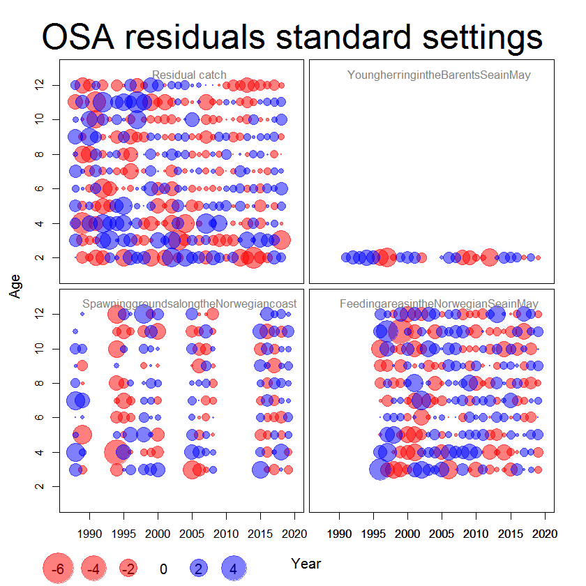

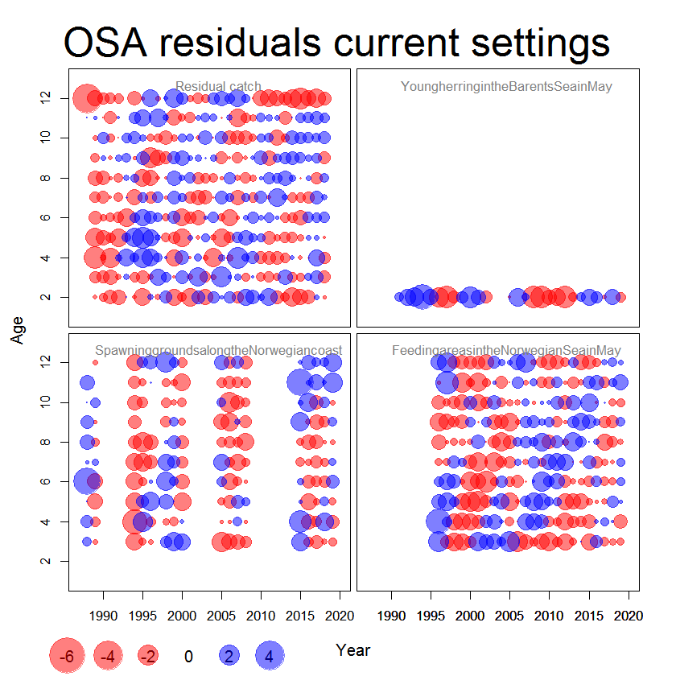

**Retrospective patterns**

```r
  retroStandard = retro(fitStandard,year = 7)
  retroCurrent = retro(fitCurrent,year = 7)
  plot(retroStandard)
  plot(retroCurrent)
```

*Note: It is less retrospective patterns when using the standard settings, which indicates that the standard settings are more appropopriate.*

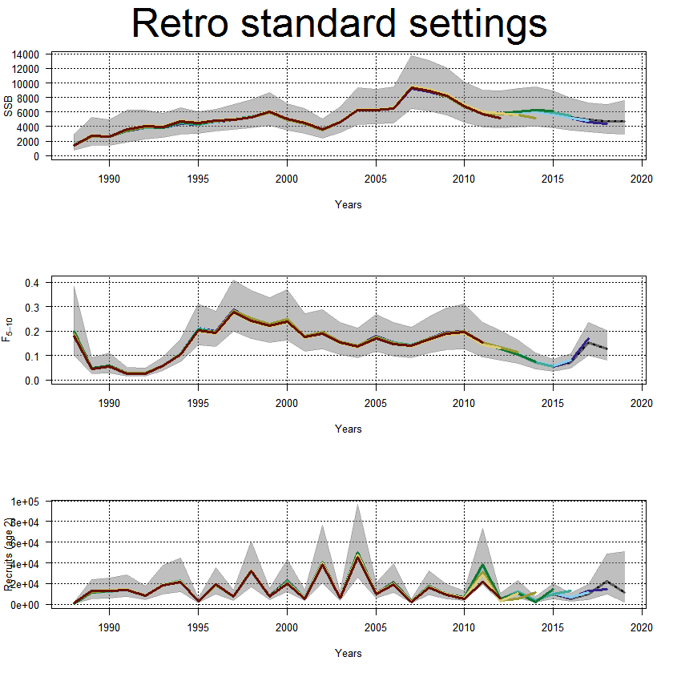

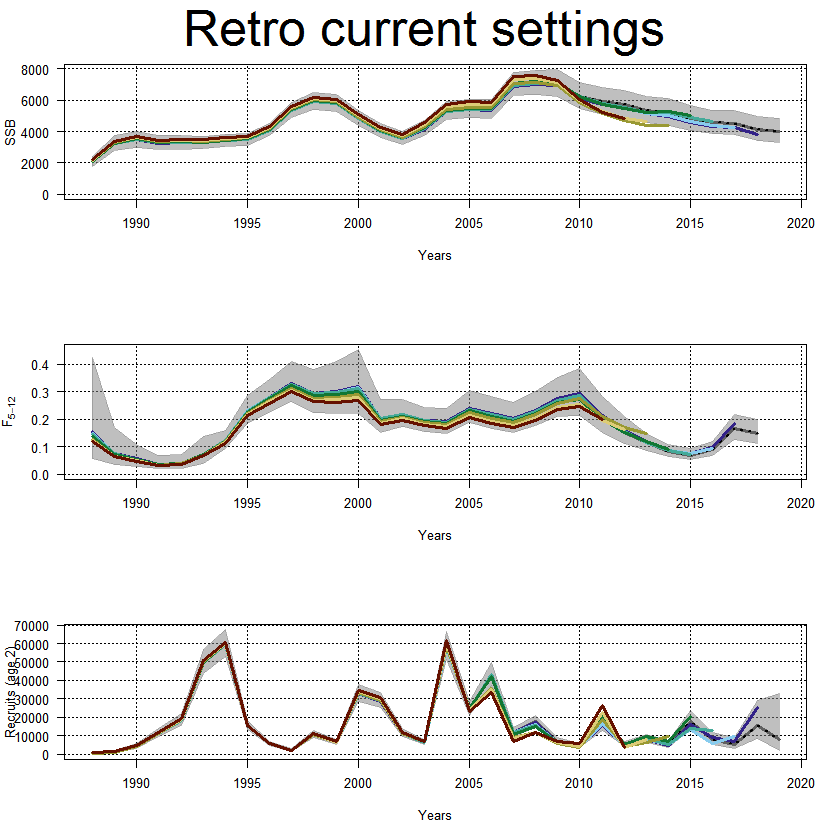

In the Norwegian Spring Spawning herring assessment it is used three survey indices in addition to the commercial catch data. We can investigate the effect of removing one or more of these surveys from the assessment model by using the `leaveout` function in SAM.

**Leaveout**

```r
  leavoutStandard= leaveout(fitStandard)
  plot(leavoutStandard)
```

*Note: Survey `FeedingareasintheNorwegianSeainMay` seems to be the survey with most information.*

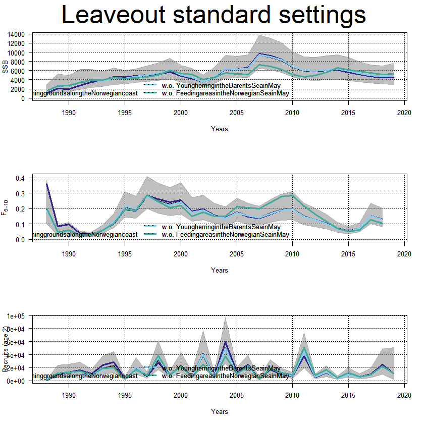

## Propose new settings

Propose new configuration settings for Norwegian Spring Spawning Herring. Key features to modify are:

1. Coupling of observation variances
2. Correlation structure of observations
3. Model for fishing mortality
4. Usage of external variances
5. Include or exclude process error
6. Recruitment

Propose several configuration settings, and argue which proposal is the best.

## TAC for 2020

The target level of exploration is calculated with the following formula:
$$\begin{align}
F_{tr}=
\begin{cases}
0.05 ,& \text{if } \text{SSB} \leq B_{lim} \\
0.14- 0.09\frac{B_{pa} - \text{SSB}}{B_{pa}-\text{B}_{lim}} ,& \text{if } \text{B}_{lim} < \text{SSB} \leq B_{pa} \\
0.14 ,& \text{if } \text{B}_{pa} < \text{SSB}
\end{cases}
\end{align}$$
where $\text{B}_{lim} = 2.5$ million tonnes. and $\text{B}_{pa} = 3.184$ million tonnes.

In 2019 it is estimated to be caught 773 750 tons of herring.

**Predict SSB January 1st. 2020**

```r
  set.seed(12345)
  forecast(fit,catchval.exact = c(773.750,0))
```

[output not shown]

We predict the SSB to be approximately 3.783 million tonnes in 1st january 2020. By using the target level of exploration formula above, we want to target the fishing mortalty to $F_{tr} = 0.14$ in 2020.

**Forecast catches in 2020 corresponding to $F_{tr}$**

```r
  set.seed(12345)
  forecast(fit,catchval.exact = c(773.750,NA), fval = c(NA,0.14))
```

[output not shown]

Estimated catch in 2020 is 503 000 tonnes, which is the advised TAC.

## Compare SAM assessment with XSAM assessment

The 2019 XSAM-assessment of herring can be found in chapter 4 in the [WGWIDE](http://www.ices.dk/sites/pub/Publication%20Reports/Expert%20Group%20Report/Fisheries%20Resources%20Steering%20Group/2019/WGWIDE/01%20WGWIDE%20Report%202019.pdf) report. Compare a SAM assessment with XSAM-options with the the assessment given in the WGWIDE report. Key features to compare are

1. Likelihood
2. Estimated parameters
3. SSB
4. F-bar
5. Recruitment
6. Retrospective plots
7. TAC